# INFO 201 Final Project

## Olympics Project

For this data set, we chose to surround the our data around the Olympic Games. We have chosen 4 data sets which has correlation with the Olympics Games such as the Olympics 2021 data set, the 120 years of Olympic history, the COVID-19 Global Dataset and the GDP Annual Growth. These data sets are included for us to answer several questions regarding the Olympics games, which are what range of height and weight classes for male and female athletes show the most success in different events, how do countries’ GDP relate to their medal counts and how do the results of the 2021 Olympics for different countries compare to that of past Olympic games?

The **Olympics 2021 Dataset** provides us which a range of data collected from the most recent Olympics games. This data sets ranges from athletes name, gender and country, event and medal count for the recent Tokyo Olympics 2021 for us to find a correlation on whether the impact of a 5 years gap from the previous Olympics Games instead of a 4-year gap present a challenge for various athletes as well as the COVID-19 Cases that the country was hit by. For that correlation, we also include the **COVID-19 Global Dataset** for us to have the COVID-19 cases data.

The **GDP Annual Growth Dataset** provides us a range of data from the year 1960 - 2020 for 264 countries. This is for us to use to find a correlation with the countries’ GDP with their medal count. For that relationship, we will also include the **120 years of Olympics history Dataset** for us to have past Olympics Data.

The reason we chose this data is because we all really enjoyed the past Tokyo Olympics Games and are excited to find correlations of the countries’ successes in Olympics Games with other aspect of the world. With all that said, let’s look at the data we have gathered.

**SUMMARY INFORMATION**

Lastly, we wanted to distinguish between the medal counts of the most recent Olympics Games with the previous one in 2016. The Tokyo Olympics Games was postpone to 2021 from 2020 due to the dire COVID-19 situation. We wanted to see if that had an effect towards the Countries’ Medal Count.

**AGGREGATED TABLE**

Average Weight of Men and Women for Olympics 2016

| Sport | Avg_Weight | Sex |
| --- | --- | --- |
| Gymnastics | 56.16667 | M |
| Gymnastics | 47.90000 | F |
| Swimming | 87.11429 | M |
| Swimming | 68.37143 | F |
| Weightlifting | 89.50000 | M |
| Weightlifting | 69.85714 | F |
| Tennis | 79.50000 | M |
| Tennis | 63.75000 | F |

| Sport | Avg_Height | Sex |
| --- | --- | --- |
| Gymnastics | 162.2500 | M |
| Gymnastics | 151.3000 | F |
| Swimming | 192.1429 | M |
| Swimming | 178.9143 | F |
| Weightlifting | 172.5000 | M |
| Weightlifting | 160.8571 | F |
| Tennis | 185.2500 | M |
| Tennis | 173.5000 | F |

GDP vs Medal Count for Olympics 2016

| Country Name | GDP2016 | total |
| --- | --- | --- |
| China | 11,233,276,536,737 | 70 |
| Germany | 3,467,498,002,104 | 42 |
| India | 2,294,797,978,292 | 2 |
| Japan | 4,922,538,141,455 | 41 |
| United States | 18,714,960,538,000 | 121 |

Medal Count in 2016 vs 2020

| Country_Name | Medals | Year |
| --- | --- | --- |
| United States | 113 | 2021 |
| United States | 121 | 2016 |
| Japan | 58 | 2021 |
| Japan | 41 | 2016 |
| China | 88 | 2021 |
| China | 70 | 2016 |
| Great Britain | 65 | 2021 |
| Great Britain | 67 | 2016 |
| Germany | 37 | 2021 |
| Germany | 42 | 2016 |
| India | 7 | 2021 |
| India | 2 | 2016 |

**FIRST CHART**

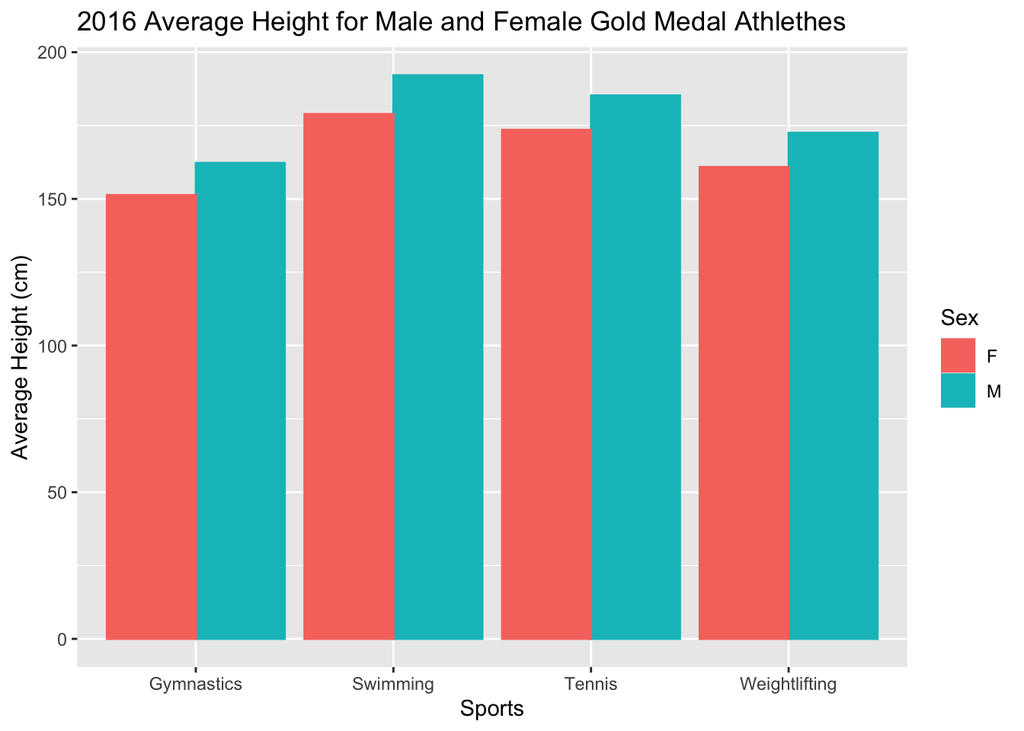

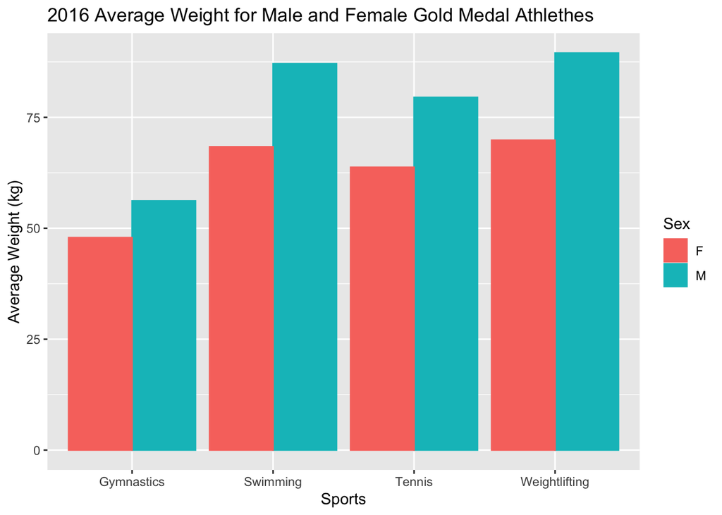

Here we can observe the difference between the Height and Weight of Gold Medalist of Male and Female Athletes of the 2016 Olympics Games. We can see that there is a difference in each sport of Weight and Height Requirements. Swimming requires their athletes to be one of the tallest among the 4 sports and Weightlifting requires its athletes to be among the heaviest. These characteristics fits the style and enviroment of the sport itself.

**SECOND CHART**

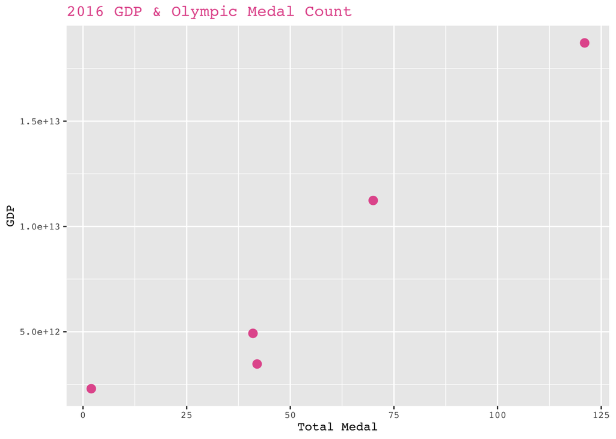

Here we can observe the direct comparison between the GDP of countries and their medal counts. If we look at the graph, we can spot a direct correlation between the two. Take United States, their GDP is high will corresponds to their medal count to be among the highest. India, on the other hand, despite having one of the largest population, their GDP is low which corresponds to their Olympic medal count to be low. This is an interesting distinction because countries with higher GDP will have more funding to invest in their national sports team which will boost their medal counts.

**THIRD CHART**

[figure not shown]